# Soil Profile Sketches

### hz.distinctness.offset

`NULL`, or quoted column name (horizon-level attribute) containing vertical offsets used to depict horizon boundary distinctness (same units as profiles). Data from `fetchOSD()` contain these offsets in the `hzd` horizon-level attribute. See [Visualization of Horizon Boundaries](https://ncss-tech.github.io/AQP/aqp/hz-boundaries.html) for details.

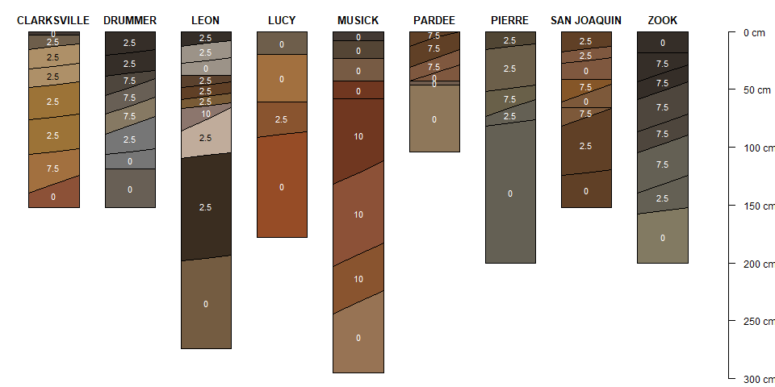

```r
# use offset values instead of horizon designations to emphasize effect
par(mar = c(0, 0, 0, 1))
plotSPC(osds, cex.names = 0.66, name.style = 'center-center', width = 0.33, hz.distinctness.offset = 'hzd', name = 'hzd')
```

### hz.topography.offset

`NULL`, or quoted column name (horizon-level attribute) containing offsets used to depict horizon boundary topography. See [Visualization of Horizon Boundaries](https://ncss-tech.github.io/AQP/aqp/hz-boundaries.html) for details.

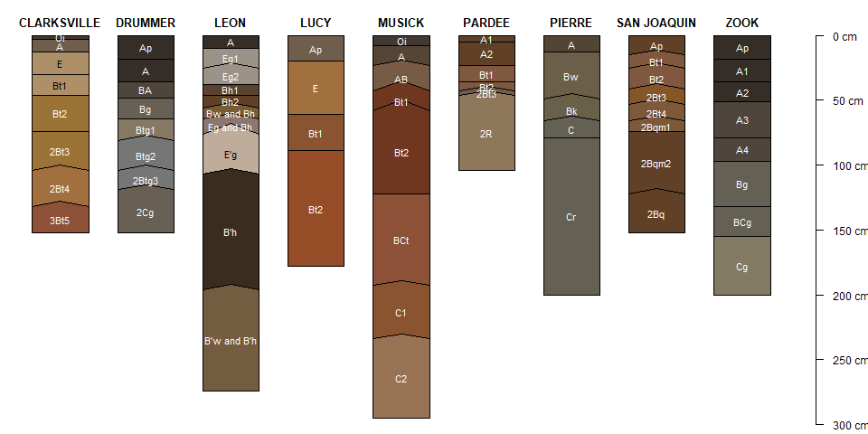

```r
# encode horizon boundary topography via vertical offset
osds$hzto <- hzTopographyCodeToOffset(osds$topography)

par(mar = c(0, 0, 0, 1))
plotSPC(osds, cex.names = 0.66, name.style = 'center-center', width = 0.33, hz.topography.offset = 'hzto')
```

### hz.boundary.lty

quoted column name (horizon-level attribute) containing line style (integers) used to encode horizon topography. See [Visualization of Horizon Boundaries](https://ncss-tech.github.io/AQP/aqp/hz-boundaries.html) for details.

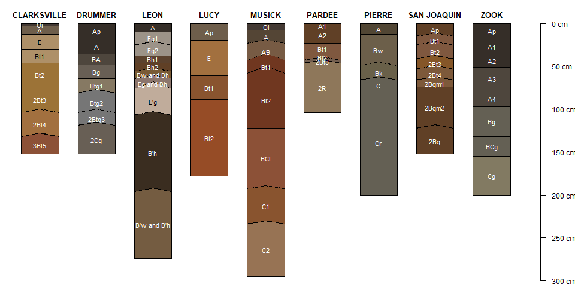

```r
# encode horizon boundary topography as line type
osds$hzto.lty <- hzTopographyCodeToLineType(osds$topography)

par(mar = c(0, 0, 0, 1))
plotSPC(osds, cex.names = 0.66, name.style = 'center-center', width = 0.33, hz.topography.offset = 'hzto', hz.boundary.lty = 'hzto.lty')
```

## Depth Axis

The depth axis is controlled via `depth.axis` argument as of aqp 2.0. The `depth.axis` argument can take two forms:

- logical: `FALSE` (suppress the depth axis) or `TRUE` (use the default depth axis style)
- a list with named elements: specify some or all of the depth axis parameters

Depth axis parameters include:

- `style`: legend style, either ‘traditional’ (aqp 1.x default), ‘compact’, or ‘tape’
- `line`: horizontal positioning, default is -2
- `cex`: scaling factor for entire axis
- `interval`: depth axis interval

As of aqp 2.x, the depth axis is truncated near `max.depth`.

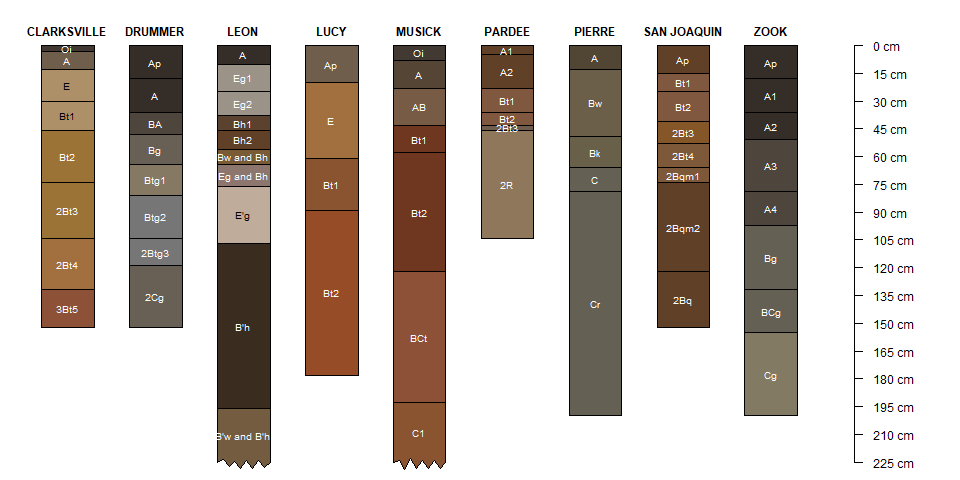

```r
par(mar = c(0, 0, 0, 4))
plotSPC(
  osds,
  cex.names = 0.6,
  name.style = 'center-center',
  width = 0.3,
  depth.axis = list(cex = 0.75, line = -1.5, interval = 15),
  max.depth = 225
  )
```

Backwards compatibility for aqp 1.x-style arguments is provided but a message is printed whenever the following arguments are used: `cex.depth.axis`, `axis.line.offset`, `plot.depth.axis`. These arguments will eventually be removed from `plotSPC()`.

If you like the depth axis as used in aqp 1.x, set `depth.axis = list(style = 'traditional')`, or for all subsequent plots: `options(.aqp.plotSPC.args = list(style = 'traditional'))`

# Secondary Annotation

## addBracket()

Add vertical brackets next to profile sketches, smart enough follow ordering adjusted with `plot.order` and `plot.order` and `relative.pos`.

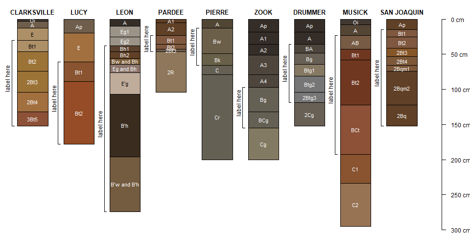

```r
par(mar = c(0, 0, 0, 1))

# random ordering of profiles
plotSPC(
  osds,
  cex.names = 0.66,
  name.style = 'center-center',
  width = 0.33,
  plot.order = sample(1:length(osds))
)

# data.frame with profile IDs,
# bracket top, bottom, and optional label
.brackets <- data.frame(
  id = profile_id(osds),
  top = minDepthOf(osds, pattern = 'B', na.rm = FALSE)$top,
  bottom = maxDepthOf(osds, pattern = 'B', top = FALSE)$bottom,
  label = 'label here'
)

# annotate "B" horizons
addBracket(.brackets, offset = - 0.45)
```

## addVolumeFraction()

Approximation of volumetric data, such as rock fragments.

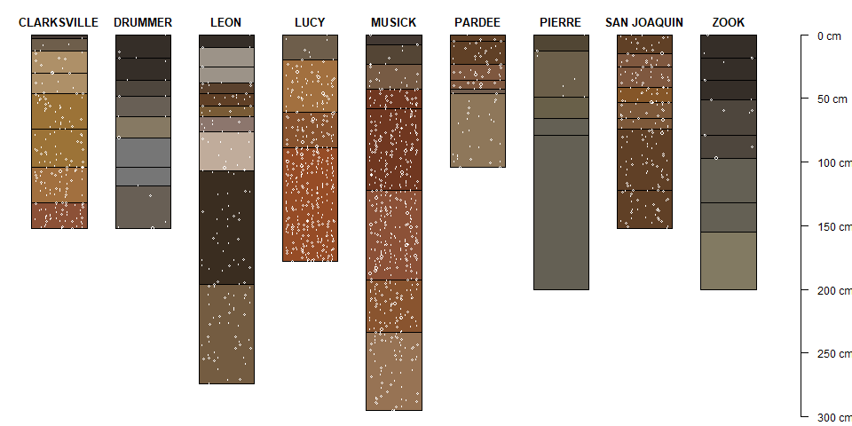

```r
par(mar = c(0, 0, 0, 1))

plotSPC(
  osds,
  cex.names = 0.66,
  name = NA,
  name.style = 'center-center',
  width = 0.33
)

# positive CIELAB A-coordinates
osds$A.coord <- pmax(0, munsell2rgb(osds$hue, osds$value, osds$chroma, returnLAB = TRUE)$A)

# interpret positive A-coordinates
# as percentages
addVolumeFraction(osds, colname = 'A.coord', col = 'white')
```

# Sketch Metadata

Sometimes you need details from a sketch for further annotation; profile ordering, depth scaling, y-offsets, and so on. This information is stored in a special environment.

```r
# re-order by max profile depth
# note this is not the same as soil depth (e.g. to contact)

# compute bottom-most horizon depth
.depths <- profileApply(osds, max)

# or, use [-style indexing and keywords
# "last horizon of each profile" and "bottom depth"
.depths <- osds[, , .LAST, .BOTTOM]

# shallow -> deep ordering
.order <- order(.depths)

# make a sketch
par(mar = c(0, 0, 0, 3))
plotSPC(osds, cex.names = 0.6, name.style = 'center-center', width = 0.3, plot.order = .order)

# get last sketch metadata
lastPP <- get("last_spc_plot", envir = aqp.env)
str(lastPP)
```

```
List of 16
 $ width         : num 0.3
 $ plot.order    : int [1:9] 6 1 2 8 4 7 9 3 5
 $ x0            : num [1:9] 1 2 3 4 5 6 7 8 9
 $ pIDs          : chr [1:9] "PARDEE" "CLARKSVILLE" "DRUMMER" "SAN JOAQUIN" ...
 $ idname        : chr "id"
 $ y.offset      : num [1:9] 0 0 0 0 0 0 0 0 0
 $ scaling.factor: num 1
 $ max.depth     : int 295
 $ n             : int 9
 $ xlim          : num [1:2] 0.6 9.9
 $ ylim          : num [1:2] 295 -15
 $ extra_x_space : num 0.9
 $ extra_y_space : num 15
 $ hz.depth.LAI  : num [1:9] NA NA NA NA NA NA NA NA NA
 $ legend.colors : chr [1:65] "#433933FF" "#6E5E4BFF" "#AE9068FF" "#AE9068FF" ...
 $ legend.data   : NULL
```

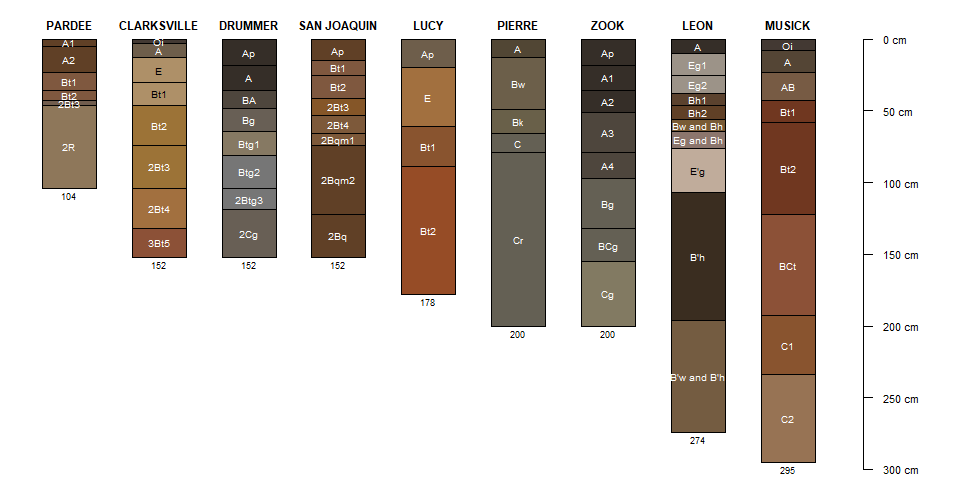

```r
# use plot order (from metadata) to annotate
text(
  x = seq_along(osds),
  y = .depths[lastPP$plot.order] + 5,
  labels = .depths[lastPP$plot.order],
  cex = 0.55
)
```

This document is based on `aqp` version 2.3.1.